# Nueve tecnologías, un solo tipo de muestra: integrar lotes con Seurat

Sesión 09 · Práctica complementaria · 17 de septiembre de 2026

Autores/as

José Antonio Ovando Ricárdez

Yalbi Itzel Balderas-Martínez

**NotaQué es este documento y cómo se relaciona con la práctica de la sesión**

Esta es una **práctica complementaria**: una segunda ruta al mismo problema, con otros datos y otros métodos.

|  | Práctica de la sesión | Esta práctica |
| --- | --- | --- |
| Datos | PBMC 3k y PBMC 10k: dos lotes | `pbmcsca`: nueve conjuntos, uno por tecnología |
| Herramientas | Bioconductor: `batchelor`, `scran`, `scater` | Seurat v5 |
| Métodos | control, fastMNN, Harmony, anclas | CCA, RPCA, Harmony, fastMNN y scVI |
| Cómo se trabajó | en clase, un método por equipo | por tu cuenta, después de la sesión |

No sustituye a la práctica de la sesión: la complementa mostrando el mismo razonamiento en el otro ecosistema de programas, que es el que se usa en las sesiones del módulo invitado.

## Objetivo

Reconocer un efecto de lote cuando la variable técnica es **la tecnología de secuenciación**, corregirlo con cinco métodos distintos dentro de Seurat, y comparar qué cambia y qué se conserva con cada uno.

## Antes de empezar

**Cuánto tarda y qué pide.** En el clúster del curso, con cuatro núcleos, la corrida completa tomó **12 minutos y 10 segundos** y usó **3.0 gigabytes** de memoria (medido el 17 de septiembre de 2026). En una computadora personal puede tardar más. No es un documento para ejecutar en medio de una clase.

**Qué se ejecuta aquí y qué no.** De los cinco métodos que se presentan, este documento ejecuta tres: **CCA, RPCA y Harmony**. Los otros dos se explican y se citan, pero no se corren, porque hoy no están disponibles en el entorno del curso:

- **fastMNN** necesita el paquete `SeuratWrappers`, que todavía no está instalado en el clúster. Está pedido al área técnica.
- **scVI** necesita Python, la biblioteca `scvi-tools` y una tarjeta gráfica (GPU, *graphics processing unit*) para ser utilizable. El clúster del curso no tiene una, así que sus resultados se dejan precalculados.

Cuando el entorno los tenga, se agregan a este documento con el mismo patrón que los otros tres: una llamada a `IntegrateLayers()` con su método.

```r
# ── ¿Dónde se está ejecutando este documento? ────────────────────────────────
# dir.exists() devuelve TRUE si la carpeta existe. La carpeta del curso solo
# existe en el clúster, así que sirve para distinguir los dos casos.

en_ken <- dir.exists("/mnt/data/bioinfo3")

# ── Biblioteca de R donde se instalan los paquetes ───────────────────────────
# Una "biblioteca" es la carpeta donde R guarda los paquetes. En el clúster, la
# biblioteca del curso es de SOLO LECTURA: nadie puede instalar ahí. Por eso
# cada persona usa una propia, dentro de su carpeta de trabajo y no en $HOME,
# que tiene una cuota de 5 gigabytes.

if (en_ken) {
  mi_lib <- file.path("/mnt/data/bioinfo3", Sys.getenv("USER"), "R-lib")
  dir.create(mi_lib, recursive = TRUE, showWarnings = FALSE)
  # .libPaths() es la lista de carpetas donde R busca paquetes. La nuestra va
  # primero para que R la revise antes que las demás.
  .libPaths(c(mi_lib, .libPaths()))
} else {
  mi_lib <- .libPaths()[1]
}

# ── ¿Está instalado un paquete? ──────────────────────────────────────────────
# system.file() devuelve la carpeta del paquete si está instalado, o un texto
# vacío si no. nzchar() es TRUE cuando el texto NO está vacío.
#
# Se usa esta función, y no requireNamespace(), porque requireNamespace() CARGA
# el paquete para responder, y en el clúster cargar algunos paquetes cierra R.

esta_instalado <- function(paquete) {
  nzchar(system.file(package = paquete))
}
```

```r
library(Seurat)      # el ecosistema de análisis de célula única de esta práctica
library(SeuratData)  # descarga conjuntos de datos ya preparados como objetos Seurat
library(ggplot2)     # gráficas
library(patchwork)   # acomodar varias gráficas en una sola figura

# Tamaño máximo de los objetos que se pueden enviar a un proceso paralelo. Sin
# esto, R se detiene con un error cuando el objeto pasa de 500 megabytes.
options(future.globals.maxSize = 1e+10)
```

## 1. Los datos: nueve tecnologías sobre el mismo tipo de muestra

`pbmcsca` reúne células mononucleares de sangre periférica (PBMC, por sus siglas en inglés: linfocitos T, linfocitos B, monocitos y células asesinas naturales o NK, *natural killer*) analizadas con **nueve tecnologías distintas de célula única**. Se construyó para comparar plataformas (Ding *et al.*, 2020).

Esa es la razón de usarlo aquí: la columna `Method` de sus metadatos dice con qué tecnología se procesó cada célula, y **esa es la fuente de efecto de lote**. El tipo de muestra es el mismo; lo que cambia es cómo se midió.

```r
# Se instala solo si falta, y en la biblioteca personal definida arriba.
# El conjunto pesa unos 56 megabytes.
if (!esta_instalado("pbmcsca.SeuratData")) {
  InstallData("pbmcsca", lib = mi_lib)
}

obj <- LoadData("pbmcsca")

# Cuántas células aportó cada tecnología.
table(obj$Method)
```

```
  10x Chromium (v2) 10x Chromium (v2) A 10x Chromium (v2) B   10x Chromium (v3)
               3362                3222                3222                3222
           CEL-Seq2            Drop-seq             inDrops            Seq-Well
                526                6584                6584                3773
         Smart-seq2
                526
```

El conjunto trae una columna `CellType` con el tipo celular ya anotado por quienes lo publicaron. La usamos como referencia biológica, igual que en la práctica de la sesión se usó la etiqueta gruesa.

```r
table(obj$CellType)
```

```
                     B cell              CD14+ monocyte
                       5020                        5550
             CD16+ monocyte                 CD4+ T cell
                        804                        7391
           Cytotoxic T cell              Dendritic cell
                       9071                         433
              Megakaryocyte         Natural killer cell
                        977                        1565
Plasmacytoid dendritic cell                  Unassigned
                        164                          46
```

## 2. Filtrado mínimo

Se conservan las células con más de mil genes detectados. `nFeature_RNA` es el número de genes con al menos una lectura en esa célula; un valor muy bajo suele venir de una célula dañada o de una gota que no contenía una célula entera.

**AdvertenciaEste filtro es didáctico, no un control de calidad completo**

Un control de calidad de verdad revisa además el número total de lecturas, el porcentaje de lecturas de genes mitocondriales y la presencia de dobletes. Eso se trabajó en la sesión 05. Aquí se recorta al mínimo para que el documento se concentre en el efecto de lote.

Hay un detalle que conviene tener presente: un umbral fijo de mil genes **castiga a unas tecnologías más que a otras**, porque no todas detectan el mismo número de genes por célula.

```r
celulas_antes <- ncol(obj)
obj <- subset(obj, subset = nFeature_RNA > 1000)

cat("Celulas antes:", celulas_antes, "- despues:", ncol(obj), "\n")
```

```
Celulas antes: 31021 - despues: 10434
```

```r
table(obj$Method)
```

```
  10x Chromium (v2) 10x Chromium (v2) A 10x Chromium (v2) B   10x Chromium (v3)
               2172                 844                 831                2866
           CEL-Seq2            Drop-seq             inDrops            Seq-Well
                504                1810                 545                 350
         Smart-seq2
                512
```

**Pregunta 2.1.** Compara las dos tablas de células por tecnología, antes y después del filtro. ¿Qué tecnologías pierden más células, y qué tiene eso que ver con cómo miden?

**Pregunta 2.2.** Si una tecnología pierde la mayoría de sus células y otra no pierde casi ninguna, ¿qué le ocurre a la comparación entre lotes que viene después?

## 3. Las respuestas de la sección 2

**2.1.** Pierden más las tecnologías que detectan menos genes por célula, como Drop-seq, inDrops y Seq-Well, que reparten menos lecturas entre más células. Las de 10x v3 y las de placa, Smart-seq2 y CEL-Seq2, llegan a más genes por célula y casi no pierden. El umbral no mide calidad biológica: mide profundidad, que es una propiedad de la tecnología.

**2.2.** Aparece un efecto de lote **adicional al técnico**: los lotes ya no solo difieren en cómo midieron, sino en cuántas y cuáles células quedaron. Si además un tipo celular es poco abundante, puede desaparecer por completo de un lote, y entonces se vuelve imposible distinguir «esta población no está» de «el filtro se la llevó».

## 4. Separar el objeto por lote

Seurat versión 5 guarda los datos en **capas** (*layers*). Separar la capa de cuentas por tecnología permite que cada lote se normalice por su cuenta y que después los métodos de integración sepan qué comparar con qué (Hao *et al.*, 2024).

```r
obj[["RNA"]] <- split(obj[["RNA"]], f = obj$Method)

# Layers() muestra los nombres de las capas: una de cuentas por tecnología.
Layers(obj[["RNA"]])
```

```
 [1] "counts.Smart-seq2"        "counts.CEL-Seq2"
 [3] "counts.10x_Chromium_v2_A" "counts.10x_Chromium_v2_B"
 [5] "counts.10x_Chromium_v3"   "counts.Drop-seq"
 [7] "counts.Seq-Well"          "counts.inDrops"
 [9] "counts.10x_Chromium_v2"   "data.Smart-seq2"
[11] "data.CEL-Seq2"            "data.10x_Chromium_v2_A"
[13] "data.10x_Chromium_v2_B"   "data.10x_Chromium_v3"
[15] "data.Drop-seq"            "data.Seq-Well"
[17] "data.inDrops"             "data.10x_Chromium_v2"
```

## 5. Qué se ve sin corregir nada

Este es el **control**: el punto de comparación obligatorio. Sin él no se puede afirmar que un método mejoró algo.

```r
obj <- NormalizeData(obj)        # ajusta por profundidad y toma logaritmos
obj <- FindVariableFeatures(obj) # elige los genes que más varían
obj <- ScaleData(obj)            # centra y escala, para que ningún gen domine
obj <- RunPCA(obj, npcs = 30)    # resume miles de genes en 30 componentes

obj <- FindNeighbors(obj, dims = 1:30, reduction = "pca")
obj <- FindClusters(obj, resolution = 2, cluster.name = "grupos_sin_integrar")
```

```
Modularity Optimizer version 1.3.0 by Ludo Waltman and Nees Jan van Eck

Number of nodes: 10434
Number of edges: 412798

Running Louvain algorithm...
Maximum modularity in 10 random starts: 0.8982
Number of communities: 49
Elapsed time: 0 seconds
```

```r
obj <- RunUMAP(obj, dims = 1:30, reduction = "pca",
               reduction.name = "umap.sin.integrar")
```

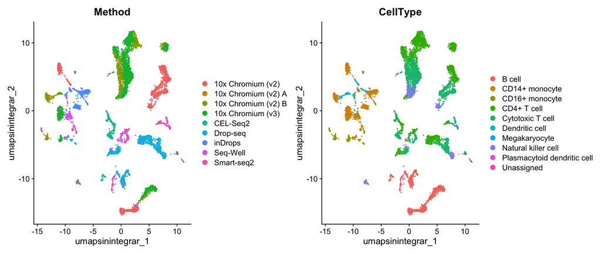

Figura 1: Sin corregir: a la izquierda, las células coloreadas por tecnología; a la derecha, por tipo celular.

```r
DimPlot(obj, reduction = "umap.sin.integrar",
        group.by = c("Method", "CellType"), label.size = 2)
```

**Pregunta 5.1.** Compara las dos gráficas. ¿Las células de un mismo tipo celular quedan juntas, o quedan separadas según la tecnología?

**Pregunta 5.2.** ¿Qué pasaría si, sin corregir nada, anotaras tipos celulares a partir de estos grupos?

## 6. Las respuestas de la sección 5

**5.1.** Quedan separadas por tecnología: los linfocitos T de Drop-seq caen lejos de los linfocitos T de 10x. La variación técnica pesa más que la biológica, y la reducción de dimensionalidad muestra primero la que más pesa.

**5.2.** Tendrías grupos que son plataformas disfrazadas de tipos celulares: el mismo tipo aparecería varias veces, una por tecnología, y entre sus «marcadores» saldrían genes que solo reflejan cómo mide cada plataforma.

## 7. Cinco formas de corregirlo

Todas producen **una representación reducida nueva**, y eso importa: ninguna modifica las cuentas originales, así que la expresión diferencial se sigue haciendo sobre las cuentas sumadas por muestra y por tipo celular —el pseudobulk de la sesión 02—, con el lote dentro del modelo.

| Método | Idea en una línea | Referencia |
| --- | --- | --- |
| CCA | busca ejes de variación correlacionados entre lotes y alinea las células equivalentes | (Hao *et al.*, 2024) |
| RPCA | como CCA, pero proyectando cada lote sobre los componentes del otro; más conservador | (Hao *et al.*, 2024) |
| Harmony | mueve las células en el espacio de componentes principales, de forma iterativa, hasta mezclar los lotes | (Korsunsky *et al.*, 2019) |
| fastMNN | empareja células mutuamente más parecidas entre lotes y usa esos pares para corregir | (Haghverdi *et al.*, 2018) |
| scVI | aprende una representación latente con una red neuronal que incluye el lote como variable | (Lopez *et al.*, 2018) |

```r
obj <- IntegrateLayers(obj, method = CCAIntegration,
                       orig.reduction = "pca",
                       new.reduction = "integrated.cca", verbose = FALSE)
```

```r
obj <- IntegrateLayers(obj, method = RPCAIntegration,
                       orig.reduction = "pca",
                       new.reduction = "integrated.rpca", verbose = FALSE)
```

```r
obj <- IntegrateLayers(obj, method = HarmonyIntegration,
                       orig.reduction = "pca",
                       new.reduction = "harmony", verbose = FALSE)
```

**NotaLos dos métodos que no se ejecutan aquí**

En Seurat, fastMNN y scVI se llaman igual que los tres anteriores, con `IntegrateLayers()` y `method = FastMNNIntegration` o `method = scVIIntegration`, pero ambos viven en el paquete `SeuratWrappers`, y scVI necesita además un ambiente de Python con `scvi-tools`. El guion completo, con esas dos llamadas incluidas, está en el repositorio del curso como `scripts/R/13-integracion-pbmcsca-sesion-09.R`.

## 8. Comparar los resultados

Se agrupa y se dibuja cada representación corregida, para verla junto al control. La lista `metodos` nombra los tres que se ejecutaron; agregar otro es agregar un renglón.

```r
# Nombre para los títulos -> nombre de la reducción dentro del objeto.
metodos <- c("CCA" = "integrated.cca",
             "RPCA" = "integrated.rpca",
             "Harmony" = "harmony")

for (nombre in names(metodos)) {
  red <- metodos[[nombre]]
  # tolower() pasa a minúsculas; paste0() une textos sin espacios.
  clave <- tolower(nombre)
  obj <- FindNeighbors(obj, reduction = red, dims = 1:30)
  obj <- FindClusters(obj, resolution = 2,
                      cluster.name = paste0("grupos_", clave))
  obj <- RunUMAP(obj, reduction = red, dims = 1:30,
                 reduction.name = paste0("umap.", clave))
}
```

```
Modularity Optimizer version 1.3.0 by Ludo Waltman and Nees Jan van Eck

Number of nodes: 10434
Number of edges: 625153

Running Louvain algorithm...
Maximum modularity in 10 random starts: 0.8083
Number of communities: 25
Elapsed time: 1 seconds
```

```
Modularity Optimizer version 1.3.0 by Ludo Waltman and Nees Jan van Eck

Number of nodes: 10434
Number of edges: 489805

Running Louvain algorithm...
Maximum modularity in 10 random starts: 0.7978
Number of communities: 26
Elapsed time: 1 seconds
```

```
Modularity Optimizer version 1.3.0 by Ludo Waltman and Nees Jan van Eck

Number of nodes: 10434
Number of edges: 458672

Running Louvain algorithm...
Maximum modularity in 10 random starts: 0.7866
Number of communities: 24
Elapsed time: 0 seconds
```

```r
names(metodos)
```

```
[1] "CCA"     "RPCA"    "Harmony"
```

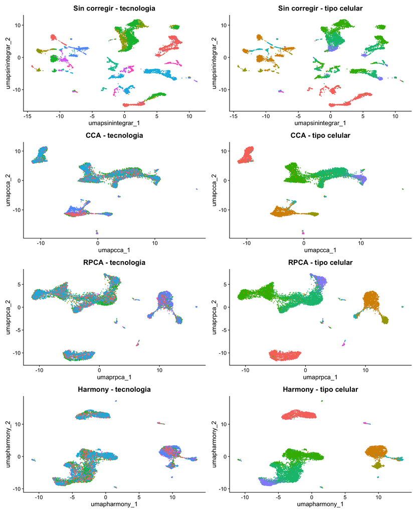

Figura 2: Cada método, coloreado por tecnología (izquierda) y por tipo celular (derecha). El control sin corregir va en el primer renglón.

```r
paneles <- list(
  DimPlot(obj, reduction = "umap.sin.integrar", group.by = "Method") +
    ggtitle("Sin corregir - tecnologia") + NoLegend(),
  DimPlot(obj, reduction = "umap.sin.integrar", group.by = "CellType") +
    ggtitle("Sin corregir - tipo celular") + NoLegend()
)

for (nombre in names(metodos)) {
  clave <- tolower(nombre)
  paneles <- c(paneles, list(
    DimPlot(obj, reduction = paste0("umap.", clave), group.by = "Method") +
      ggtitle(paste(nombre, "- tecnologia")) + NoLegend(),
    DimPlot(obj, reduction = paste0("umap.", clave), group.by = "CellType") +
      ggtitle(paste(nombre, "- tipo celular")) + NoLegend()
  ))
}

wrap_plots(paneles, ncol = 2)
```

**Pregunta 8.1.** ¿Qué método mezcla más las tecnologías? ¿Es el mismo que conserva mejor separados los tipos celulares?

**Pregunta 8.2.** Mirando solo estas gráficas, ¿puedes afirmar que la corrección no borró biología? ¿Por qué?

## 9. Las respuestas de la sección 8

**8.1.** Casi nunca es el mismo. CCA mezcla con fuerza y puede juntar tipos celulares parecidos; RPCA es más conservador y suele dejar los lotes algo separados, pero preserva mejor las diferencias biológicas; Harmony queda en medio. Cuál conviene depende de si los lotes contienen o no las mismas poblaciones (Luecken *et al.*, 2022).

**8.2.** No. Una gráfica de dos dimensiones no distingue entre «los lotes se mezclaron» y «dos tipos celulares se fundieron». Para afirmarlo hacen falta números: una métrica de mezcla por lote, una de separación por tipo celular, y la comprobación de que ninguna población del control desapareció. Eso es justamente lo que se calcula en la práctica de la sesión.

## 10. Un gen concreto: CD8A

`CD8A` es un marcador de linfocitos T citotóxicos. Comparar su distribución entre los grupos de antes y los de después ayuda a ver si los grupos siguen teniendo sentido biológico.

**ImportanteLo que se compara aquí no es expresión corregida**

La integración actúa sobre la representación reducida, **no sobre las cuentas**. Lo que cambia entre estas gráficas no es el valor de `CD8A` en cada célula, sino cómo quedaron repartidas las células entre los grupos.

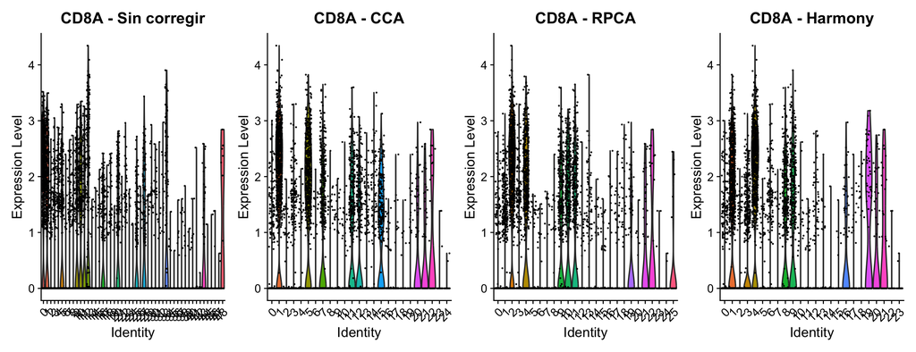

Figura 3: Expresión de CD8A en los grupos obtenidos sin corregir y con cada método.

```r
columnas <- c("grupos_sin_integrar",
              paste0("grupos_", tolower(names(metodos))))
titulos <- c("Sin corregir", names(metodos))

# Map() aplica la misma función a dos listas en paralelo: aquí, a cada columna
# de grupos con su título.
violines <- Map(function(col, titulo) {
  VlnPlot(obj, features = "CD8A", group.by = col) +
    NoLegend() + ggtitle(paste("CD8A -", titulo))
}, columnas, titulos)

wrap_plots(violines, nrow = 1)
```

**Pregunta 10.1.** ¿En cuál de los agrupamientos queda `CD8A` concentrado en menos grupos? ¿Qué te dice eso sobre lo que separaba a los grupos antes de corregir?

## 11. La respuesta de la sección 10

**10.1.** Suele concentrarse más después de corregir. Antes, los linfocitos T citotóxicos estaban repartidos en varios grupos, uno por tecnología, así que `CD8A` aparecía en todos ellos. Al corregir, esas células se juntan y el marcador queda en menos grupos: es la señal de que los grupos empezaron a seguir a la biología en lugar de a la plataforma.

## 12. Volver a unir las capas

Al terminar la integración, las capas se unen de nuevo. Es necesario para buscar marcadores, hacer expresión diferencial o dibujar la expresión de un gen sobre todas las células a la vez. Unir las capas **no borra** las representaciones integradas.

```r
obj <- JoinLayers(obj)
Layers(obj[["RNA"]])
```

```
[1] "data"       "counts"     "scale.data"
```

## Errores comunes

- **Quedarse con un solo método.** Sin comparar contra el control sin corregir no hay forma de saber si el método mejoró o empeoró las cosas.
- **Leer la mezcla en el UMAP.** Una reducción a dos dimensiones oculta lo que ocurre en las otras veintiocho.
- **Hacer expresión diferencial sobre los datos integrados.** La representación corregida sirve para agrupar y visualizar; la expresión diferencial va sobre las cuentas, con el lote como covariable (Squair *et al.*, 2021).
- **Corregir sin haber diagnosticado.** Si el lote coincide con la condición biológica, ningún método puede separarlos, y corregir en ese caso fabrica un resultado que parece bueno y no lo es.

## Lo que te llevas

- El efecto de lote no siempre es un donante o una corrida: aquí es la tecnología con la que se midió cada célula.
- Los cinco métodos producen una representación nueva y dejan las cuentas intactas.
- Mezclar más no es corregir mejor: lo que importa es mezclar los lotes **sin** fundir los tipos celulares.
- Un umbral fijo, aplicado a tecnologías con profundidades distintas, introduce su propio sesgo antes de que empiece la corrección.

## Para pensar

Este conjunto de datos tiene una propiedad que casi ningún experimento real tiene: las nueve tecnologías midieron el mismo tipo de muestra, así que las diferencias entre lotes son técnicas casi por definición y mezclarlas del todo es una meta razonable.

En un experimento propio, con pacientes distintos en cada corrida, esa meta deja de ser razonable. ¿Qué tendría que cumplir tu diseño experimental para que mezclar los lotes por completo siguiera siendo lo correcto, y cómo lo comprobarías antes de corregir?

## Referencias

- Ding J. *et al.* (2020). Systematic comparison of single-cell and single-nucleus RNA-sequencing methods. *Nature Biotechnology* 38, 737–746. https://doi.org/10.1038/s41587-020-0465-8
- Hao Y. *et al.* (2024). Dictionary learning for integrative, multimodal and scalable single-cell analysis. *Nature Biotechnology* 42, 293–304. https://doi.org/10.1038/s41587-023-01767-y
- Korsunsky I. *et al.* (2019). Fast, sensitive and accurate integration of single-cell data with Harmony. *Nature Methods* 16, 1289–1296. https://doi.org/10.1038/s41592-019-0619-0
- Haghverdi L. *et al.* (2018). Batch effects in single-cell RNA-sequencing data are corrected by matching mutual nearest neighbors. *Nature Biotechnology* 36, 421–427. https://doi.org/10.1038/nbt.4091
- Lopez R. *et al.* (2018). Deep generative modeling for single-cell transcriptomics. *Nature Methods* 15, 1053–1058. https://doi.org/10.1038/s41592-018-0229-2
- Luecken M. D. *et al.* (2022). Benchmarking atlas-level data integration in single-cell genomics. *Nature Methods* 19, 41–50. https://doi.org/10.1038/s41592-021-01336-8
- Squair J. W. *et al.* (2021). Confronting false discoveries in single-cell differential expression. *Nature Communications* 12, 5692. https://doi.org/10.1038/s41467-021-25960-2